# Chapter 1: Understanding R

# A Gentle Introduction to R

Chapter Summary: This chapter introduces the R programming language and the foundations required for using it to solve data-oriented problems.

Many students find the R programming language troubling. Beginners find the syntax baffling and arcane. More experienced programmers also express frustration with R because it is different from many commonly-used programming languages. Basically, both groups of students struggle with R because it asks them to think about their work in new ways. This chapter introduces students to the basics of R programming. First, the philosophy behind R is explained to help students orient themselves to its assumptions and nuances. Second, the chapter explains the rationale for using R to teach data-oriented topics to undergraduates. Finally, the chapter discusses RStudio, an integrated development environment for R, R programming basics, and some common errors students encounter when working with R.

## The R Philosophy

The R philosophy includes a few assumptions about programming that may be unfamiliar even to experienced students of technology. The R philosophy can be summed up with a few simple phrases.

- Data analysis is the primary purpose of R.
- Programming is a means to an end in R.
- Flexibility is more important than consistency in R.

Statisticians and mathematicians developed R to meet their specific disciplinary needs. Initially, the primary audience for the software consisted of highly trained academics and their students with specific analytical needs. For this reason, R is intensely focused on tasks related to data analysis. Many other programming languages like Java, for example, focus on the development of applications and programs. If a student’s experience is primarily with Java, R will feel strange because it wasn’t designed for creating applets, command line programs or interactive graphical applications. R was made for data analysis, and therefore, will lack many of the features familiar to those with experience in languages for application development.

Many programming languages like Java were created by people who really like writing programs and developing applications. Moreover, such programming languages were written to be as general as possible. In theory, a person can write a program in Java to address pretty much any kind of application. Languages like Java have been used for games, web sites, business applications, and anything else one might imagine. In contrast to Java, R was written to serve people who thought of programming as a means to an end. Statisticians and mathematicians are less interested in programming for its own sake than professional programmers. They focus instead on what programs can do for them such as help them to complete their analytical tasks more quickly and accurately.

Since the R community has been developing its packages for over 20 years, the language has grown a great deal. While many programming languages focus on the consistency of the code, R is more concerned with flexibility. In other words, R developers try to ensure that its users have as much freedom as possible. This is somewhat different from the philosophy of other programming languages. For example, Java frequently retires old versions of its packages requiring older programs to be updated to use its new libraries. Because R sacrifices consistency for flexibility, R can often feel unnecessarily complicated.

For the purposes of this course, students should understand and embrace the R philosophy. This course teaches students about data analysis. The programs students will write in this course are a means to that end. Although R can feel complicated at times, once students get the hang of it, they will be able to achieve a great deal with rather compact programs.

## Rationale for using R

If R is such an unusual language, then why do we use it for this course? Despite its challenges, R has some important advantages that make its use compelling for this course.

- R is free.
- R works on almost any desktop computer with Windows, Mac or Linux.
- R is powerful and awesome once people buy into its philosophy.
- R has been adopted by many disciplines in the sciences, social sciences, humanities and arts.
- R developers have contributed packages addressing an impressive array of real-world applications.

Basically, R provides the best balance available for the modern student. It is used widely in academic and professional settings. It is used across the great breadth of disciplines pursued by undergraduate students today. In short, R provides the best platform to address the diverse needs of the undergraduate students who typically enroll in this course.

## Mathematics and Statistics

Given the early history of R, it is no surprise that R has powerful features for handling mathematics and statistics. For example, suppose a student wants to explore the correlation between two variables: temperature in degrees Celsius and ice cream sales in US dollars.

Pierce, Rod. (5 Jan 2016). “Correlation”. Math Is Fun. Retrieved 10 Apr 2016 from http://www.mathsisfun.com/data/correlation.html

Consider the following sample data:

Ice Cream Sales vs Temperature

| temp | sales |
| --- | --- |
| 14.2 | 215 |
| 16.4 | 325 |
| 11.9 | 185 |
| 15.2 | 332 |
| 18.5 | 406 |
| 22.1 | 522 |
| 19.4 | 412 |
| 25.1 | 614 |
| 23.4 | 544 |
| 18.1 | 421 |
| 22.6 | 445 |
| 17.2 | 408 |

For this example, we want to know if people buy more ice cream when the weather is warmer. Statisticians use a correlation coefficient to measure the relationship between two variables. If the two variables are positively correlated, then the correlation coefficient will be close to 1. If the two variables are negatively correlated, the correlation coefficient will be close to -1. Finally, if the variables are uncorrelated, then the correlation coefficient will be close to 0. R makes this kind of calculation fairly straight-forward.

```r
cor(data, method="pearson")
```

```
##            temp     sales
## temp  1.0000000 0.9575066
## sales 0.9575066 1.0000000
```

The sample code above uses the `cor()` function to calculate the correlation coefficient. In this example, the table of values was stored in a variable called `data`. The `cor()` function calculates the correlation coefficient using a technique called Pearson’s product moment correlation coefficient, `method="pearson"`.

The output of this command is printed directly below the command. The correlation coefficient in this case is 0.9575066. In other words, based on this sample data we have some evidence supporting the idea that people buy more ice cream when it’s hot outside.

## Graphics

Quite frankly, if this is all R did for us, we would not use it for this class. Excel has similar functions that work well for this kind of task. But R makes it possible for us to explore such relationships graphically. For example, it is common to use a scatter plot when displaying the relationship between two variables

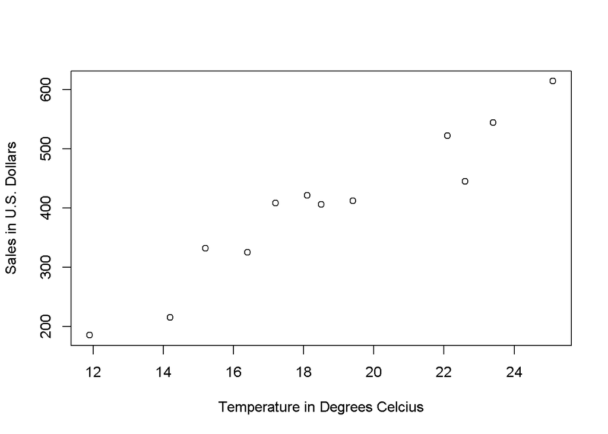

Ice Cream Sales vs. Temperature

```r
plot(data$temp,
     data$sales,
     xlab="Temperature in Degrees Celcius",
     ylab="Sales in U.S. Dollars")
```

The code above creates a scatter plot with the temperature data plotted on the x axis and sales data plotted on the y axis. The example labels the x and y axes appropriately.

## Data Science Libraries

In addition to R’s mathematical and graphical abilities, R also provides many packages for data science algorithms that we will discuss in this class. For example, we will use packages to support the following data mining topics in this course.

- Data Mining Packages
  - Decision Trees
  - Neural Networks
  - Support Vector Machines
  - Naive Bayes Classification
- Network Science Packages

It is difficult to find software with the great range of capabilities offered by R.

# R Basics

R is free. RStudio is free. You can obtain them from the following websites.

Main R website: https://www.r-project.org/

Download R: http://cran.mirrors.hoobly.com/

Main RStudio website: https://www.rstudio.com/products/rstudio/

Download RStudio: https://www.rstudio.com/products/rstudio/download3/

## R Syntax

R commands are called *functions*. Perhaps the most important function in R is the `help()` function. The `help()` function provides additional information about any other function in R.

Functions have *arguments* which control the specific aspects of how a function is executed. For example, if we want to read the help file for the `cor()` function, we would call the help function with `cor` as its argument.

```
help(cor)
```

Arguments always appear between the parentheses in an R function.

In many cases, we will want to use more than one argument in a function. Arguments are separated by commas in R. For example, if we decide to specify that we want to see the help file for the `cor()` function in the `stats` package, we would type:

```
help(cor, package="stats")
```

In some cases, arguments take the form of `argument="option"` or `argument=option`.

The generic form of R functions, therefore, is:

```
function(argument1, argument2=option, ...)
```

In addition to functions, R allows users to define *variables*. Variables store values in our programs. For example, if we want to store the name “Al” into a variable called `who`, we could type:

```r
who <- "Al"
```

The `<-` symbol is referred to as the assignment operator. We use this to assign a value to a variable.

We type the name of the variable to see the value it stores.

```r
who
```

```
## [1] "Al"
```

R has many *operators* for mathematical purposes including arithmetic and boolean operators.

With functions and operators, we will be able to construct complex programs for data analysis.

# Common Tasks in R

## Set Working Directory

Since we will be using R to analyze data stored in files, we will need to be able to perform file management tasks easily. This requires the user to understand the concept of a *working directory*. The working directory in R is the location in the computer’s file system where R is currently looking for files. If we want to see the current working director in R, we use the `getwd()` function:

```r
getwd()
```

```
## [1] "C:/Users/tlombardi/Documents/repository/telombardi.github.io/data_mining_R/understandingR"
```

Now that we know where R is looking for our files, we might want to know what it sees. To print the file names in the current working directory, we can use the `dir()` function:

```
dir()
```

In many cases, we will need to change the working directory in R. We use the `setwd()` function for this purpose. We can change the working directory to the `C:\temp` folder with the following function:

```r
setwd("C:/temp")
```

You should become very comfortable with these functions because we will frequently need to change directories to load data into R.

## Loading Data

Since R is designed for data analysis, it is no surprise that it has many functions for loading data. First, R already comes with many built in data sets. To explore the data sets already available in R, use the `data()` function.

If you want to load a specific data set such as the `cars` data set, call the `data()` function with `cars` as its only argument.

```r
data(cars)
```

This command loads the `cars` data set and stores it in a variable named `cars`. To see the data stored in the varialbe, just type `cars`.

```r
cars
```

```
##    speed dist
## 1      4    2
## 2      4   10
## 3      7    4
## 4      7   22
## 5      8   16
## 6      9   10
## 7     10   18
## 8     10   26
## 9     10   34
## 10    11   17
## 11    11   28
## 12    12   14
## 13    12   20
## 14    12   24
```

[output cut: 36 more lines]

Although this is extremely convenient, analysts often need to load data from files or the internet. R provides many ways to do this. For the sake of clarity, we will discuss one particular file type, the comma separated value file or CSV for short. The `read.csv()` function loads data in CSV format into R. For example, if we want to load data from the following location over the internet, http://introcs.cs.princeton.edu/java/data/elements.csv, we would type:

```r
data <- read.csv("http://introcs.cs.princeton.edu/java/data/elements.csv")
```

This function downloads the CSV from internet and stores its contents into a variable called `data`.

If we downloaded the same file to the `C:\temp` folder, we would load it with a slightly different command:

```
data <- read.csv("C:/temp/elements.csv")
```

Practice loading data into R. We will be performing this task often.

## Installing and Loading Packages

In many cases, developers need to load R *packages*, software modules that extend R’s capabilities. First, packages must be installed into the R system. After installation, packages must be loaded into memory to make them available to R programs.

To install the `stringr` package, for example, we type:

```
install.packages("stringr")
```

To make `stringr` functions available in R, type:

```
library(stringr)
```

The stringr functions and documentation are now available in R. To test this, look at the help documents for the function.

```
help(package="stringr")
```

Since many data mining tasks require additional libraries, you should practice installing and loading libraries to master this skill.

# Common Errors in R

Many students express frustation due to errors in R. In this section, we highlight a few common errors to help smooth out the rough patches.

## Error: could not find function “gtest”

```
gtest()
```

This error can mean a few different kinds of things. Literally, R does not know of any function called `gtest()`. There are a few different reasons why this might be:

1. There is in fact no such function because you mistyped something. Review the documentation and double-check your typing.
2. This is such a function, but its packages has not been installed and loaded. In this case, install and load the package and try again.

## Error in file(file, “rt”) : cannot open the connection

Students often receive this error when first working with data files.

```
data <- read.csv("bacon.csv")
```

1. The file in fact does not exist. Confirm that you correctly typed the file name. Confirm that the file is in fact where you think it is.
2. The file exists, but is not in R’s current working directory. Move the file to R’s working directory or change R’s working directory to the location where the file can be found.

# Summary

In this chapter, we outlined the basics of working with R including its philosophy, basic syntax and common tasks. In the next chapter, we will introduce the data mining concepts that form the primary focus of this course.

# References

R Core Team (2016). R: A language and environment for statistical computing. R Foundation for Statistical Computing, Vienna, Austria. URL https://www.R-project.org/.